# R Example LASSO: House prices

R Example for the lecture: **Advanced model specification with LASSO**

Guest Lecture: Advanced Applied Econometrics, Master of Agricultural and Food Economics, SS2023, Uni Bonn

*Hugo Storm (hugo.storm@ilr.uni-bonn.de), May 2023*

This is an example of how to use LASSO for model selection in the context of predicting house prices.

Data and example from Verbeek (2008) A Guide to Modern Econometrics (3th), section 3.4

```r
## Clear workspace
rm(list = ls())

# Set random number seed
set.seed(13)

# Load packages
library(glmnet)
library(plotmo)
```

### Load and prepare the data

```r
#Import data as a data frame
dat<-read.csv("housing.csv", sep=";")
```

Have a look at the data. We have sale prices on houses (“PRICE”) as well as information about different attributes of each house (for details see Verbeek)

```r
dat
```

| AIRCO | BATHRMS | BEDROOMS | DRIVEWAY | FULLBASE | GARAGEPL | GASHW | LOTSIZE | PREFAREA | PRICE | RECROOM | STORIES |
| --- | --- | --- | --- | --- | --- | --- | --- | --- | --- | --- | --- |
| 0 | 1 | 3 | 1 | 1 | 1 | 0 | 5850 | 0 | 42000 | 0 | 2 |
| 0 | 1 | 2 | 1 | 0 | 0 | 0 | 4000 | 0 | 38500 | 0 | 1 |
| 0 | 1 | 3 | 1 | 0 | 0 | 0 | 3060 | 0 | 49500 | 0 | 1 |
| 0 | 1 | 3 | 1 | 0 | 0 | 0 | 6650 | 0 | 60500 | 1 | 2 |
| 0 | 1 | 2 | 1 | 0 | 0 | 0 | 6360 | 0 | 61000 | 0 | 1 |
| 1 | 1 | 3 | 1 | 1 | 0 | 0 | 4160 | 0 | 66000 | 1 | 1 |
| 0 | 2 | 3 | 1 | 1 | 2 | 0 | 3880 | 0 | 66000 | 0 | 2 |
| 0 | 1 | 3 | 1 | 0 | 0 | 0 | 4160 | 0 | 69000 | 0 | 3 |
| 0 | 1 | 3 | 1 | 1 | 0 | 0 | 4800 | 0 | 83800 | 1 | 1 |
| 1 | 2 | 3 | 1 | 0 | 1 | 0 | 5500 | 0 | 88500 | 1 | 4 |

[output cut: 536 more lines]

```r
NA
NA
```

Prepare a dataframe including all explanatory variables as well as interaction terms between all explanatory variables

```r
XVars <- c("LOTSIZE","BATHRMS"
           ,"DRIVEWAY","GARAGEPL","GASHW"
           ,"PREFAREA","RECROOM","AIRCO"
           ,"BEDROOMS","STORIES","FULLBASE")

# Get interaction terms
df <- model.matrix( ~.^2-1, data=subset(dat,
                                       select =XVars ))
df <- as.data.frame(df)
```

Define squared terms for certain variables. We only want squared terms for variables that are not dummies.

```r
df$BEDROOMS2 = dat$BEDROOMS^2
df$BATHRMS2 = df$BATHRMS^2
df$STORIES2 = df$STORIES^2
df$GARAGEPL2 = df$GARAGEPL^2
df$LOTSIZE2 = df$LOTSIZE^2
```

### Run Lasso using the glmnet package

With “alpha=1” you get an Lasso estimate, with “alpha=0” you get ridge regression and with values between 0-1 we get an elastic net.

For further details see:

“An Introduction to glmnet” https://cran.r-project.org/web/packages/glmnet/vignettes/glmnet.pdf Or Hastie et al 2015. Statistical Learning with Sparsity, chapter “3.7 Computational Details and glmnet” pp. 50. http://web.stanford.edu/~hastie/StatLearnSparsity/

```r
lasso_mod <- glmnet(df,dat$PRICE,alpha=1, family='gaussian')
```

Plot selection path

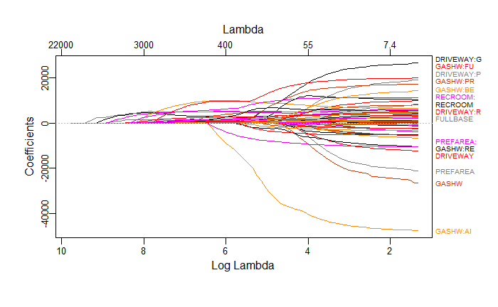

```r
plot_glmnet(lasso_mod, label=15)
```

Compare model selection path to ridge (setting alpha=0 to get ridge regression)

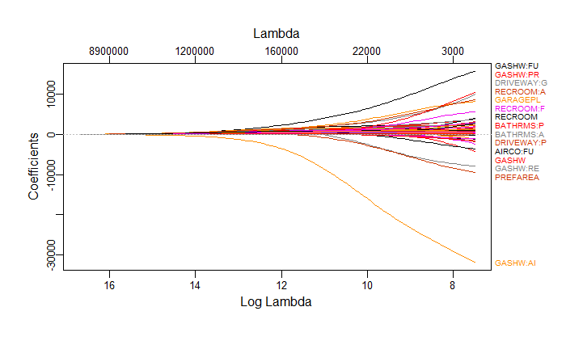

```r
#Ridge
ridge_mod <- glmnet(df,dat$PRICE,alpha=0)
plot_glmnet(ridge_mod, label=15)
```

Compare model selection path to elastic net (setting alpha in the rage 0-1)

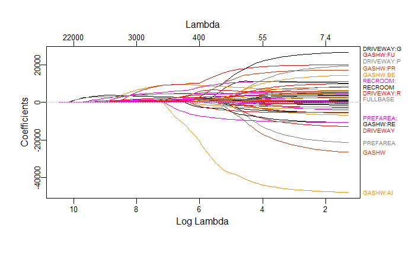

```r
#Elastic net with alpha 0.5
elastic_mod <- glmnet(df,dat$PRICE,alpha=0.5)
plot_glmnet(elastic_mod, label=15)
```

Run cross-validation for model selection

```r
cvfit <- cv.glmnet(as.matrix(df),dat$PRICE,nfolds =20)
```

Plot selection path, This plot gives you the out of sample prediction error for different values of lambda. Based on this plot we can determine an “optimal” model specification in terms of the out-of-sample prediction error.

Note it is common practices to check for two specific values. First, we check where the out of sample prediction error is smallest this is the point indicated with the left vertical line. The other points is the value for lambda where the prediction error is still within 1 standard deviation of the error for the best model (the right vertical line). Typically the second point is chosen for the “best” model specification (note that there is not really theoretical motivation for this approach, this is more a convention that is typically applied).

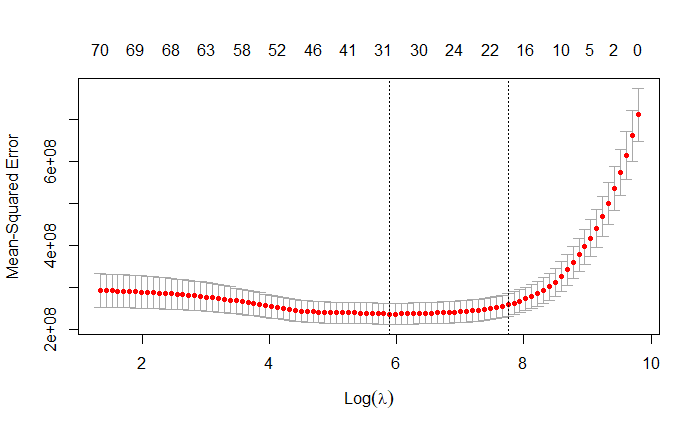

```r
plot(cvfit)
```

Get the model with the lowest error (indicated be the left vertical line in the plot)

```r
coef(cvfit ,s ="lambda.min")
```

```
72 x 1 sparse Matrix of class "dgCMatrix"
                             s1
(Intercept)        2.811088e+04
LOTSIZE            .
BATHRMS            .
DRIVEWAY           .
GARAGEPL           .
GASHW              .
PREFAREA           .
RECROOM            .
AIRCO              .
BEDROOMS           3.578214e+02
STORIES            4.082067e+03
FULLBASE           .
LOTSIZE:BATHRMS    1.128101e+00
LOTSIZE:DRIVEWAY   5.576440e-01
LOTSIZE:GARAGEPL   .
LOTSIZE:GASHW      .
LOTSIZE:PREFAREA   3.184044e-01
LOTSIZE:RECROOM    .
LOTSIZE:AIRCO      9.552846e-02
LOTSIZE:BEDROOMS   2.713854e-01
LOTSIZE:STORIES    .
LOTSIZE:FULLBASE   1.057384e+00
BATHRMS:DRIVEWAY   2.545267e+03
BATHRMS:GARAGEPL   1.174967e+03
BATHRMS:GASHW      .
BATHRMS:PREFAREA   5.073466e+03
BATHRMS:RECROOM    .
BATHRMS:AIRCO      4.797599e+03
BATHRMS:BEDROOMS   .
BATHRMS:STORIES    3.652223e+02
BATHRMS:FULLBASE   .
DRIVEWAY:GARAGEPL  .
DRIVEWAY:GASHW     8.418895e+02
DRIVEWAY:PREFAREA  1.174636e+03
DRIVEWAY:RECROOM   .
DRIVEWAY:AIRCO     .
DRIVEWAY:BEDROOMS  3.330364e+02
DRIVEWAY:STORIES   4.727235e+02
```

[output cut: 19 more lines]

```
RECROOM:AIRCO      6.310396e+03
RECROOM:BEDROOMS   .
RECROOM:STORIES    .
RECROOM:FULLBASE   2.997996e+03
AIRCO:BEDROOMS     .
AIRCO:STORIES      1.418456e+03
AIRCO:FULLBASE     .
BEDROOMS:STORIES   .
BEDROOMS:FULLBASE  .
STORIES:FULLBASE   .
BEDROOMS2          .
BATHRMS2           .
STORIES2           .
GARAGEPL2          .
LOTSIZE2           .
```

Get the model with error within 1sd error of best model (indicated be the right vertical line in the plot)

```r
coef(cvfit ,s ="lambda.1se")
```

```
72 x 1 sparse Matrix of class "dgCMatrix"
                            s1
(Intercept)       3.776301e+04
LOTSIZE           .
BATHRMS           .
DRIVEWAY          .
GARAGEPL          .
GASHW             .
PREFAREA          .
RECROOM           .
AIRCO             .
BEDROOMS          .
STORIES           .
FULLBASE          .
LOTSIZE:BATHRMS   7.222799e-01
LOTSIZE:DRIVEWAY  .
LOTSIZE:GARAGEPL  .
LOTSIZE:GASHW     .
LOTSIZE:PREFAREA  7.372915e-02
LOTSIZE:RECROOM   .
LOTSIZE:AIRCO     2.578652e-01
LOTSIZE:BEDROOMS  2.778490e-01
LOTSIZE:STORIES   7.148148e-01
LOTSIZE:FULLBASE  8.508237e-01
BATHRMS:DRIVEWAY  4.530989e+03
BATHRMS:GARAGEPL  1.286722e+03
BATHRMS:GASHW     .
BATHRMS:PREFAREA  4.328968e+03
BATHRMS:RECROOM   .
BATHRMS:AIRCO     4.961284e+03
BATHRMS:BEDROOMS  .
BATHRMS:STORIES   2.192967e+02
BATHRMS:FULLBASE  .
DRIVEWAY:GARAGEPL .
DRIVEWAY:GASHW    .
DRIVEWAY:PREFAREA .
DRIVEWAY:RECROOM  .
DRIVEWAY:AIRCO    .
DRIVEWAY:BEDROOMS 1.093565e+02
DRIVEWAY:STORIES  .
```

[output cut: 19 more lines]

```
RECROOM:AIRCO     3.314416e+03
RECROOM:BEDROOMS  .
RECROOM:STORIES   .
RECROOM:FULLBASE  .
AIRCO:BEDROOMS    .
AIRCO:STORIES     2.820156e+02
AIRCO:FULLBASE    .
BEDROOMS:STORIES  .
BEDROOMS:FULLBASE .
STORIES:FULLBASE  .
BEDROOMS2         .
BATHRMS2          .
STORIES2          .
GARAGEPL2         .
LOTSIZE2          .
```